# ASM - Exercise week 8

Anne-Kathleen Malchow & Tobias Krüger

April 29, 2021

# 8H1

Load the dataset:

```r
library(brms)
library(rethinking)
data(tulips)
d <- tulips
str(d)
```

```
## 'data.frame':    27 obs. of  4 variables:
##  $ bed   : Factor w/ 3 levels "a","b","c": 1 1 1 1 1 1 1 1 1 2 ...
##  $ water : int  1 1 1 2 2 2 3 3 3 1 ...
##  $ shade : int  1 2 3 1 2 3 1 2 3 1 ...
##  $ blooms: num  0 0 111 183.5 59.2 ...
```

We want to fit the following model, as developed in section 8.3, apart from the intercepts:
$$b_i\sim Normal\left(\mu_i,\sigma\right)$$
$$\mu_i=\alpha_{bed[i]}+\beta_w\cdot\left(w_i-\bar w\right)+\beta_s\cdot\left(s_i-\bar s\right)+\beta_{ws}\cdot\left(w_i-\bar w\right)\cdot\left(s_i-\bar s\right)$$
$$\alpha_j\sim Normal(0.5,0.25); j=1,2,3$$
$$\beta_w\sim Normal(0,0.25)$$
$$\beta_s\sim Normal(0,0.25)$$
$$\beta_ws\sim Normal(0,0.25)$$
$$\sigma\sim Exponential(1)$$
with b indicating `blooms`, w indicating `water` and s indicating `shade`.

As described in the book (page 254), we pre-center the predictor variables and scale the outcome by its maximum (both make it easier to specify priors and to make sampling more efficient):

```r
d$blooms_std <- d$blooms / max(d$blooms)
d$water_cent <- d$water - mean(d$water)
d$shade_cent <- d$shade - mean(d$shade)
```

Fit the model with unique intercepts for each level of `bed`:

```r
m.8H1 <-
  brm(data = subset(d, select = c(blooms_std, bed, water_cent, shade_cent)),
      family = gaussian(link = "identity"),
      formula = blooms_std ~ 0 + bed + water_cent + shade_cent + water_cent:shade_cent,
      prior = c(prior(normal(0.5, 0.25), class = b),
                prior(normal(0, 0.25), class = b, coef = "water_cent"),
                prior(normal(0, 0.25), class = b, coef = "shade_cent"),
                prior(normal(0, 0.25), class = b, coef = "water_cent:shade_cent"),
                prior(exponential(1), class = sigma))
  )
```

Let’s look at the priors that have been used:

```r
prior_summary(m.8H1)
```

```
##              prior class                  coef group resp dpar nlpar bound
##  normal(0.5, 0.25)     b
##  normal(0.5, 0.25)     b                  beda
##  normal(0.5, 0.25)     b                  bedb
##  normal(0.5, 0.25)     b                  bedc
##    normal(0, 0.25)     b            shade_cent
##    normal(0, 0.25)     b            water_cent
##    normal(0, 0.25)     b water_cent:shade_cent
##     exponential(1) sigma
##        source
##          user
##  (vectorized)
##  (vectorized)
##  (vectorized)
##          user
##          user
##          user
##          user
```

Note, that the three `bed`-coefficients used the default prior for slopes (class = b), while the predictors `water` and `shade` and their interaction used specific priors set with the `coef`-option.

And the model fit summary:

```r
summary(m.8H1)
```

```
##  Family: gaussian
##   Links: mu = identity; sigma = identity
## Formula: blooms_std ~ 0 + bed + water_cent + shade_cent + water_cent:shade_cent
##    Data: subset(d, select = c(blooms_std, bed, water_cent,  (Number of observations: 27)
## Samples: 4 chains, each with iter = 2000; warmup = 1000; thin = 1;
##          total post-warmup samples = 4000
##
## Population-Level Effects:
##                       Estimate Est.Error l-95% CI u-95% CI Rhat Bulk_ESS
## beda                      0.28      0.04     0.19     0.36 1.00     5845
## bedb                      0.40      0.04     0.31     0.48 1.00     5834
## bedc                      0.41      0.04     0.33     0.49 1.00     6143
## water_cent                0.21      0.03     0.14     0.27 1.00     5968
## shade_cent               -0.11      0.03    -0.17    -0.06 1.00     6412
## water_cent:shade_cent    -0.14      0.04    -0.22    -0.07 1.00     5910
##                       Tail_ESS
## beda                      3054
## bedb                      2953
## bedc                      2991
## water_cent                2772
## shade_cent                2733
## water_cent:shade_cent     2614
##
## Family Specific Parameters:
##       Estimate Est.Error l-95% CI u-95% CI Rhat Bulk_ESS Tail_ESS
## sigma     0.13      0.02     0.10     0.18 1.00     2746     2604
##
## Samples were drawn using sampling(NUTS). For each parameter, Bulk_ESS
## and Tail_ESS are effective sample size measures, and Rhat is the potential
## scale reduction factor on split chains (at convergence, Rhat = 1).
```

Seems like there is no significant difference between the intercepts of beds *b* and *c*, but one to bed *a*.

To get an overview of our results, we plot some posterior probability intervals for each fitted parameter:

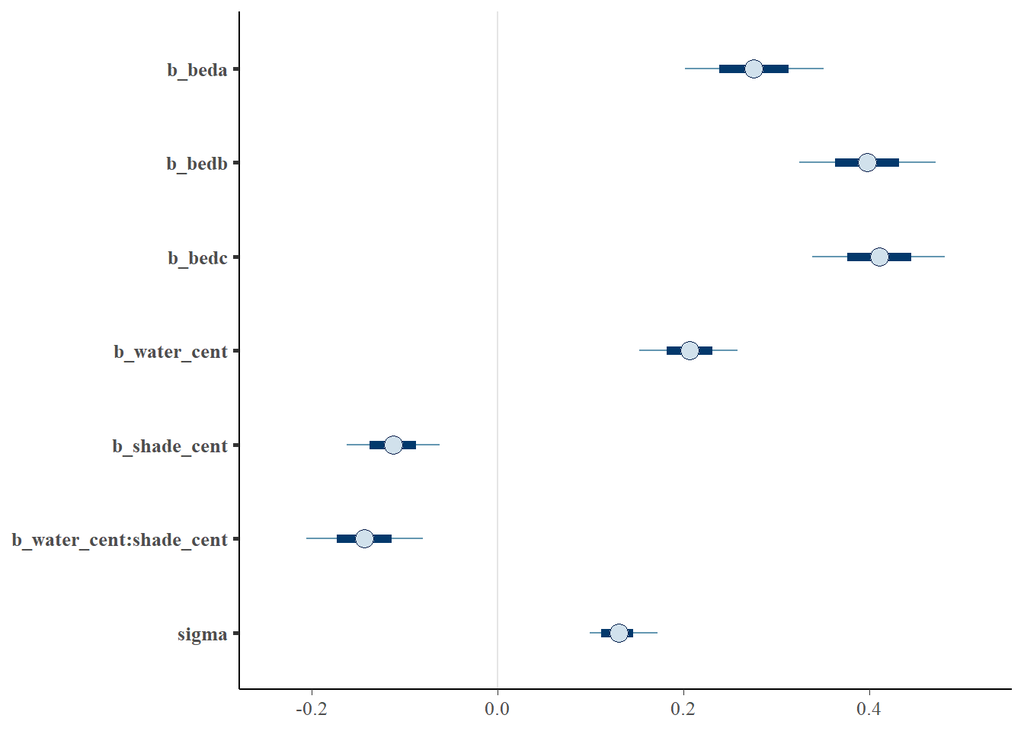

```r
mcmc_plot(m.8H1, point_est = "mean", prob = .6, prob_outer = .91)
```

The point denotes the posterior mean, the bar ist the 60% probability interval, and the line shows the 91% probability interval. The parameters for the predictors are similar as in the example in the book, but the intercept is now detailed for each bed (their mean should approximately give the common intercept used in the book).

We are mostly interested in the three unique intercepts, so let’s look at their posteriors more closely:

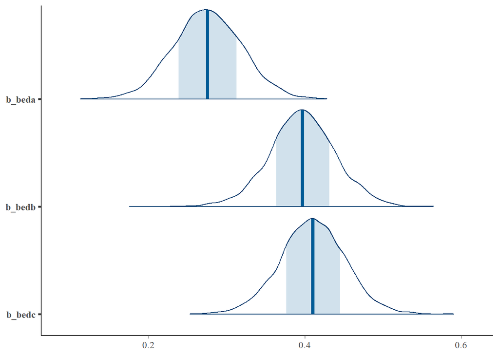

```r
mcmc_plot(m.8H1,
          pars = c("beda", "bedb", "bedc"),
          type = "areas",
          point_est = "mean", prob = .6, prob_outer = 1)
```

Compute the contrast between all three beds (page 156):

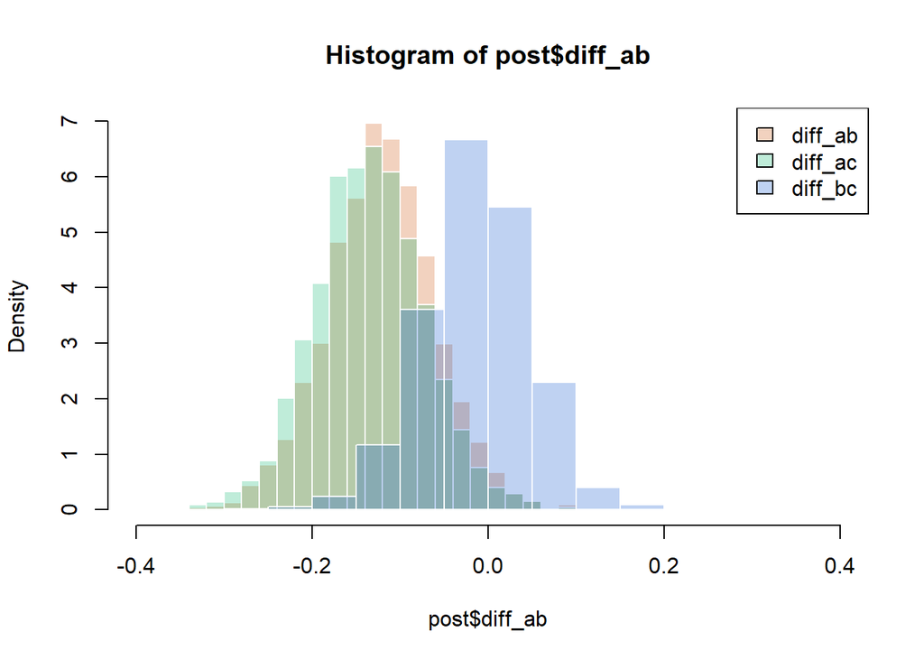

```r
post <- posterior_samples(m.8H1)[c("b_beda", "b_bedb", "b_bedc")]
post$diff_ab <- post$b_beda - post$b_bedb
post$diff_ac <- post$b_beda - post$b_bedc
post$diff_bc <- post$b_bedb - post$b_bedc

# plot contrasts
hist(post$diff_ab, 20, col=rgb(.8,.3,0,1/4), border = FALSE, freq = FALSE, xlim=c(-0.4,.4))
hist(post$diff_ac, 20, col=rgb(0,.7,.4,1/4), border = FALSE, freq = FALSE, add = TRUE)
hist(post$diff_bc, 20, col=rgb(0,.3,.8,1/4), border = FALSE, freq = FALSE, add = TRUE)
legend("topright", legend = c("diff_ab", "diff_ac", "diff_bc"),
       fill = c(rgb(.8,.3,0,1/4), rgb(0,.7,.4,1/4), rgb(0,.3,.8,1/4)))
```

All else being equal (i.e. the conditions of water and shade), the number of blooms is likely to be similar in beds *b* and *c* (the corresponding blue histogram is centred around zero), while this number is also consistently higher than in bed *a* (orange and green histograms almost entirely in the negative half).

# 8H2

Fit common intercept model:

```r
m.8H2 <-
  brm(data = subset(d, select = c(blooms_std, bed, water_cent, shade_cent)),
      family = gaussian(link = "identity"),
      formula = blooms_std ~ 1 + water_cent + shade_cent + water_cent:shade_cent,
      prior = c(prior(normal(0.5, 0.25), class = Intercept),
                prior(normal(0, 0.25), class = b, coef = "water_cent"),
                prior(normal(0, 0.25), class = b, coef = "shade_cent"),
                prior(normal(0, 0.25), class = b, coef = "water_cent:shade_cent"),
                prior(exponential(1), class = sigma))
  )
```

Compute WAIC:

```r
m.8H1 <- add_criterion(m.8H1, "waic")
```

```
## Warning:
## 5 (18.5%) p_waic estimates greater than 0.4. We recommend trying loo instead.
```

```r
m.8H2 <- add_criterion(m.8H2, "waic")
```

```
## Warning:
## 3 (11.1%) p_waic estimates greater than 0.4. We recommend trying loo instead.
```

We take the warning messages seriously and compute PSIS-LOO:

```r
m.8H1 <- add_criterion(m.8H1, "loo")
m.8H2 <- add_criterion(m.8H2, "loo")
```

When comparing the PSIS-LOO estimates with `loo_compare()`, it uses the elpd_loo estimates by default, where greater elpd_loo values indicate a better model. The `loo_compare()` function lists the best performing model first and then reports the elpd_loo differences of the other models to the first, along with their standard errors:

```r
(w <- loo_compare(m.8H1, m.8H2, criterion = "loo"))
```

```
##       elpd_diff se_diff
## m.8H1  0.0       0.0
## m.8H2 -1.4       2.7
```

Compare WAIC differences:

```r
(w <- loo_compare(m.8H1, m.8H2, criterion = "waic"))
```

```
##       elpd_diff se_diff
## m.8H1  0.0       0.0
## m.8H2 -1.7       2.6
```

No serious difference.

According to the PSIS-LOO (and WAIC) criterion, the model with categorical (unique) intercepts performs better, even though it uses 2 more parameters than the model with a common intercept. However, the elpd_loo difference is in the same order of magnitude as its standard error and hence the difference in model performance is not very clear, it is rather uncertain in itself (or “not significant” in classical speak).

If we wish to compare the models on the deviance scale, i.e. the WAIC as it is used in the book, we only have to multiply by -2:
$$WAIC=−2\cdot elpd_{WAIC}=−2\cdot (lppd−p_{WAIC})$$

We can see this in the `waic()` output, as for example:

```r
waic(m.8H1)
```

```
##
## Computed from 4000 by 27 log-likelihood matrix
##
##           Estimate  SE
## elpd_waic     14.0 3.3
## p_waic         6.0 1.3
## waic         -28.0 6.6
##
## 5 (18.5%) p_waic estimates greater than 0.4. We recommend trying loo instead.
```

Let’s look at the posterior distributions of the `bed` coefficients (i.e. the categorical intercepts) again:

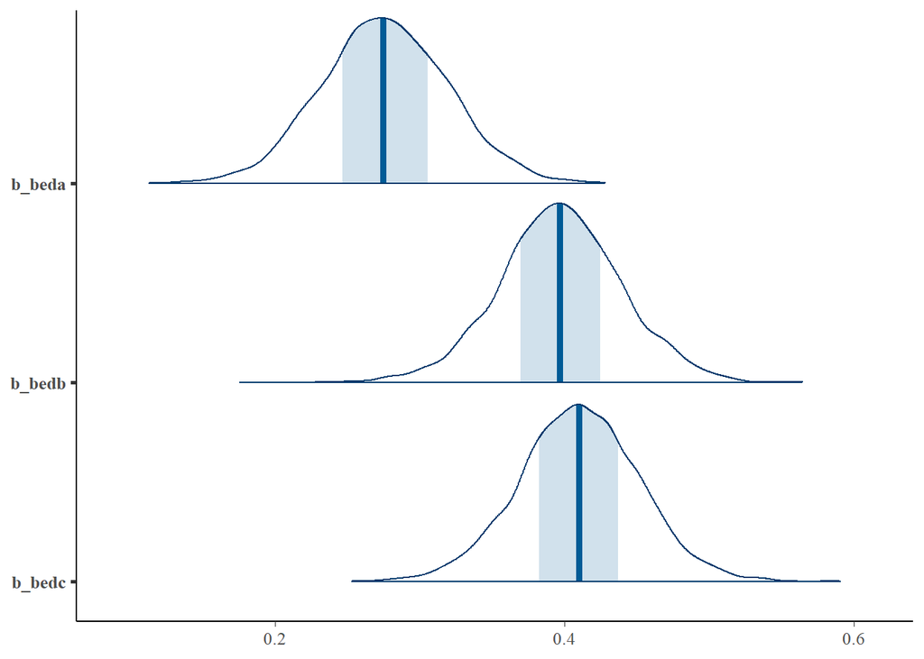

```r
mcmc_plot(m.8H1, pars=c("beda", "bedb", "bedc"), type = "areas")
```

As already discussed above under 8H1, bed *a* seems to be different from *b* and *c*, in terms of the number of blooms that the tulips in it produce. The posterior distributions of their intercepts overlap only partially, so there is a good chance of a true difference in the tulip beds. This difference can only be captured by the model with unique intercepts, which allows it to make more reliable out-of-sample predictions. Hence, it scores higher in PSIS-LOO (and WAIC), but not over and above the standard error of PSIS-LOO (and WAIC), probably because of the overlapping posterior distributions of the unique intercepts.